# Evaluating Parsimonious Classifiers for ARDS Subphenotypes

BMIN503 Final Project

Heather Giannini

## Overview

Acute respiratory distress syndrome (ARDS) is a high morbid condition of respiratory failure, resulting from a myriad of insults, including infection (most notably recently, COVID19), trauma, and other underlying etiologies. We are investigating a recently published family of parsimonious models for identifying subphenotypes in this disease. Clinical trajectory of ARDS can be highly divergent , and yet we do not have a clear understanding of the biological basis for vastly different outcomes and clinical behavior. This project will compare the assignments of two similar but slightly different biomarker-based algorithms. The parsimonious models use a cytokine, interleukin-6 or interleukin-8, both markers of a hyperinflammatory state, and couple this measurement with the patient’s level of soluble tumor necrosis factor receptor 1 (sTNFR1) and bicarbonate level. We will apply both IL6- and IL8- based models, evaluate how the population is categorized into the two subphenotypes, “Hyperinflammatory” and “Hypoinflammatory” and then correlate both clinical features and protein associations. This work was done in consultation with Dr. Nuala Meyer (Pulmonary and Critical Care) and Dr. Pratik Sinha (UCSF, Clinical Respiratory Physiology and Biostatistics) and Dr.Todd Miano (PharmD, Dept of Epidemiology). >Nuala Meyer provides primary mentorship for this project, providing expertise in interleukin dynamics of ARDS and associated critical-illness syndromes like sepsis. She has published previously on dynamics of IL6 and IL8 expression in conditions like neutropenia and sepsis. >Dr. Pratik Sinha derived these parsimonious models after initial derivation of subphenotype classes (Hyper and Hypoinflamm) via Latent Class analysis of ARDS population. He applied these classifiers to our patient data to assign phenotypes. >Dr. Todd Miano is an expert in epidemiology and study design and provided considerable expertise in coding variables and obtaining data from Penn Data Store to encode bicarbonate for the preliminary variables that were sent to Dr. Sinha for phenotype assignment.

Final Project GitHub Repository: https://github.com/gianninh/BMIN503_Final_Project

## Introduction

Acute respiratory distress syndrome (ARDS) is a devastating pulmonary condition with high patient-level variability that has extremely high mortality and long-term morbidity in survivors. In clinical trials and observational studies for ARDS, two clinical subphenotypes - distinguished by plasma levels of inflammatory proteins and correlating with 30-d mortality - have been consistently identified by latent class analysis (LCA). These two classes are termed “Hyperinflammatory” and “Hypoinflammatory”. These phenotypes demonstrate heterogeneous treatment response to multiple ARDS therapies, including steroids (in COVID19 ARDS). Although iterations of parsimonious models for assigning these LCA classes based on biomarker combinations have similar operating characteristics, their agreement at the patient level has not been directly compared. We hypothesized that the performance of these models may vary in the context of clinical factors that disproportionately affect expression of the plasma proteins used for subphenoytype assignment

This project will evaluate these biomarker-based Parsimonious Models for ARDS subphenotypes. We will apply the models to our ARDS cohort, a subcohort of the Molecular Epidemiology of Sepsis in the ICU (MESSI) sepsis cohort. We will then test associations of these class assignments with various clinical characteristics, including medical comorbidities, biomarker protein levels, laboratory values (ie. white blood cell count). Importantly, we will compare the assignments of two different models, which may vary based on the biomarker used, either IL6 or IL8, two similar cytokines that are typically congruent but may be proportionally different in certain clinical circumstances.

## Methods

471 critically ill patients with ARDS were enrolled in the study within 24 hours of admission to the intensive care unit. Laboratory values and clinical features were extracted from the EHR and input into a redcap data repository. ARDS was defined per Berlin criteria. Plasma proteins (IL6, IL8, sTNFR1) were measured by electrochemiluminescence on blood obtained <24hrs of ICU admission. We applied two parsimonious models for LCA subphenotypes [IL6/bicarbonate/sTNFR1] or [IL8/bicarbonate/sTNFR1] which return probability of assignment to Hyperinflammatory class. Comorbidities were compared between predicted model assignments using the Chi Square or Fisher’s Exact tests. Association of neutropenia (ANC <1000) with class assignments for both models was performed using Fisher’s Exact test.

Derivation of Parsimonious Classifiers for ARDS https://www.ncbi.nlm.nih.gov/pmc/articles/PMC7543720/ Development and Validation of Parsimonious Algorithms to Classify ARDS Phenotypes: Secondary Analyses of Randomised Controlled Trials

### Comparing the IL6- and IL8- Model Assignments

First, we will look at descriptive characteristics of the IL6 and IL8-based models for distribution of probabilities and IL6/IL8 levels. Here we will also calculate an IL6:IL8 ratio, and test the association of this ratio (continuous variable) with the categorical assignments.

The two datasets we are reading in contain measures for each MESSI sample ID (each ID is a patient enrolled in the study), with corresponding IL6, IL8, sTNFR1 and bicarbonate level on day 1. The two datasets below also contain the subphenotype class assignments resulting from use of either IL6- or IL8- based model. Finally, the probability of assignment to “Hyperinflammatory” is also included.

```r
## Comparing Performance of IL6 vs IL8 models
# read in results from both models
il6mod <- read_excel("~/R_Projects/MESSI_Gene_Exp/ards pars model/ards_model2_calc_done.xlsx")
il8mod <- read_excel("~/R_Projects/MESSI_Gene_Exp/ards pars model/ards_model3_calc_done.xlsx")

head(il6mod)
```

| messi_id | IL6 | Bicarbonate | sTNFR1 | Probability | Class | Model |
| --- | --- | --- | --- | --- | --- | --- |
| 991234 | 52.97556 | 7.5 | 9580.255 | 0.763040959 | Hyperinflammatory | Model2_IL6 |
| 990793 | 15393.86133 | 13.0 | 28357.961 | 0.998944340 | Hyperinflammatory | Model2_IL6 |
| 991761 | 11997.37012 | 18.0 | 4892.200 | 0.964096548 | Hyperinflammatory | Model2_IL6 |
| 993822 | 47.91490 | 25.0 | 2413.161 | 0.007890604 | Hypoinflammatory | Model2_IL6 |
| 991441 | 55.59000 | 19.0 | 5244.769 | 0.091036640 | Hypoinflammatory | Model2_IL6 |
| 991699 | 148.63998 | 14.0 | 24490.807 | 0.850296658 | Hyperinflammatory | Model2_IL6 |

We will need to simplify and merge these in order to compare how the patients are classified by each model.

```r
# remove bicarb/sTNFR1 from one dataset so they aren't duplicated in the join
il8mod <- il8mod %>% select(-Bicarbonate, -sTNFR1)

# combine the model 2 and model 3 data for one data table for analysis
# make a new variable called IL6:IL8 ratio so we can use this in our analysis later
mod_join <- left_join(il6mod, il8mod, by="messi_id")
mod_join <- mod_join %>% select(-Model.x, -Model.y) %>%
  rename("IL6_Model"=Class.x, "IL8_Model"=Class.y) %>%
  rename("IL6_Probability"=Probability.x, "IL8_Probability"=Probability.y) %>%
  mutate("IL6:IL8"=IL6/IL8)

# summarize both models assignments
mod_join %>%
  select(IL6_Model, IL8_Model, IL6_Probability, IL8_Probability, IL6, IL8)%>%
  tbl_summary(by=IL6_Model)%>%
  modify_caption("by IL6 Model Class Assignments")
```

by IL6 Model Class Assignments

| **Characteristic** | **Hyperinflammatory**, N = 198<sup>1</sup> | **Hypoinflammatory**, N = 273<sup>1</sup> |
| --- | --- | --- |
| IL8_Model |  |  |
| Hyperinflammatory | 179 (90%) | 79 (29%) |
| Hypoinflammatory | 19 (9.6%) | 194 (71%) |
| IL6_Probability | 0.88 (0.72, 0.97) | 0.05 (0.01, 0.19) |
| IL8_Probability | 0.97 (0.83, 1.00) | 0.17 (0.03, 0.60) |
| IL6 | 1,198 (449, 4,600) | 64 (27, 150) |
| IL8 | 486 (109, 2,161) | 48 (18, 160) |

<sup>*1*</sup> n (%); Median (IQR)

We see that some of the class assignments are concordant, while some of the class assignments are discordant between IL6 and IL8.

### Evaluating Discordance in Model Probabilities

We will use a heatmap representing the probabilities for each model to demonstrate that while the models tend to agree most of the time, there are some samples which clearly diverge depending on IL6 vs IL8 analyte.

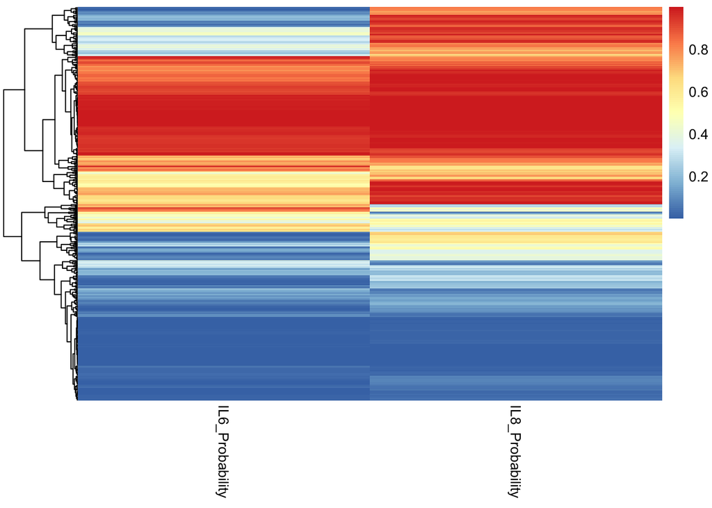

```r
mat <- mod_join %>% select(IL6_Probability, IL8_Probability)
mat <- as.matrix(mat)
pheatmap(mat, cluster_cols = F)
```

We can see there is a group of patients at the top which were low Probability in IL6, but clearly very high in IL8. And a group in the middle which were low IL8, but high IL6.

### Cohort that demonstrates class switching

There are 98 patients that switch classes between IL6- and IL8-based models.

```r
# now make a new variables coding the dual-class assignments to evaluate groups
mod_join <- mod_join %>%
  mutate(a = case_when(IL6_Probability >= 0.5 ~ "hyperIL6", IL6_Probability <= 0.5 ~ "hypoIL6"))%>%
  mutate(b = case_when(IL8_Probability >= 0.5 ~ "hyperIL8", IL8_Probability <= 0.5 ~ "hypoIL8"))%>%
  unite("combined_models", a:b, remove = TRUE)

mod_join %>% select(-messi_id, -IL6_Model, -IL8_Model) %>%
  tbl_summary(by="combined_models") %>%
  modify_caption("Both Model Assignments")
```

Both Model Assignments

| **Characteristic** | **hyperIL6_hyperIL8**, N = 179<sup>1</sup> | **hyperIL6_hypoIL8**, N = 19<sup>1</sup> | **hypoIL6_hyperIL8**, N = 79<sup>1</sup> | **hypoIL6_hypoIL8**, N = 194<sup>1</sup> |
| --- | --- | --- | --- | --- |
| IL6 | 1,286 (420, 5,400) | 1,160 (506, 1,972) | 86 (38, 224) | 53 (24, 128) |
| Bicarbonate | 16.0 (13.0, 19.0) | 19.0 (16.0, 21.0) | 19.0 (17.0, 23.0) | 23.0 (20.0, 26.0) |
| sTNFR1 | 10,797 (7,392, 15,753) | 7,561 (5,388, 10,155) | 6,942 (4,516, 10,343) | 3,243 (1,996, 5,104) |
| IL6_Probability | 0.91 (0.75, 0.97) | 0.68 (0.59, 0.77) | 0.22 (0.08, 0.36) | 0.02 (0.01, 0.10) |
| IL8 | 647 (143, 2,447) | 31 (18, 59) | 351 (156, 828) | 26 (15, 56) |
| IL8_Probability | 0.98 (0.90, 1.00) | 0.31 (0.28, 0.41) | 0.82 (0.68, 0.93) | 0.06 (0.02, 0.20) |
| IL6:IL8 | 2 (1, 5) | 24 (20, 35) | 0 (0, 1) | 2 (1, 5) |

<sup>*1*</sup> Median (IQR)

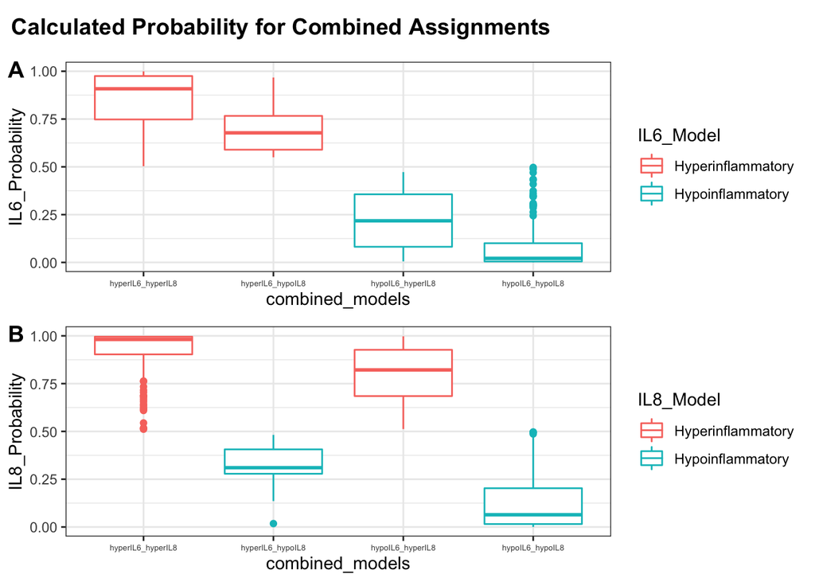

```r
p1 <- ggplot(mod_join, aes(x=combined_models, y=IL6_Probability, color=IL6_Model)) +
  geom_boxplot() +
  theme_bw() +
  theme(axis.text.x = element_text(size = 5))
p2 <- ggplot(mod_join, aes(x=combined_models, y=IL8_Probability, color=IL8_Model)) +
  geom_boxplot() +
  theme_bw() +
  theme(axis.text.x = element_text(size = 5))
plot_row <- plot_grid(
  p1, p2,
  labels = "AUTO", ncol = 1
)

# now add the title
title <- ggdraw() +
  draw_label(
    "Calculated Probability for Combined Assignments",
    fontface = 'bold',
    x = 0,
    hjust = 0
  ) +
  theme(
    # add margin on the left of the drawing canvas,
    # so title is aligned with left edge of first plot
    plot.margin = margin(0, 0, 0, 7)
  )
plot_grid(
  title, plot_row,
  ncol = 1,
  # rel_heights values control vertical title margins
  rel_heights = c(0.1, 1)
)
```

It does appear that the probabilities - particularly for IL6 Model - are less extreme, from 0.88 - 0.68 for Hyper and 0.05 - 0.22 for Hypo. IL8 probabilities mellow a bit as well, but maybe not as much.

The more interesting thing here is that the IL8 values are **higher** in the hypoinflammatory group per IL6 model, which is likely why the IL8 Model tends to put them in hyperinflamm.

**So who are these patients who have relatively higher IL8, despite a lower IL6 value?**

### Acute Clinical Variables

Next, we will bring in a dataset of clinical variables for each subject. These reflect details about acute illness and demographics including: **apacheIII, los, race, sex, age, hospMort30, mort90, sepsis source** but has a lot of other variables that we will not be working with.

```r
# load in full MESSI clinical dataset, this is over 3000 patients
working_MESSIdata2021_08 <- read_dta("~/R_Projects/MESSI_Gene_Exp/ards pars model/working MESSIdata2021_08.dta")
head(working_MESSIdata2021_08)
```

| pt | AKIN_date | AKIN | aRRT | AKIN_day | AKIN_time | AKIN_stage | baseCreFinal | everHd | esrd | crePhase | kEver | kDate | kRRT | kDay | kTime | kStage | akiExclude | apacheIII | year | admitTimePDS | dischargeTimePDS | time_zero_pds | zeroDay | los | covid_patient | covid_sample_date | adm_source | icuEver | race | … |
| --- | --- | --- | --- | --- | --- | --- | --- | --- | --- | --- | --- | --- | --- | --- | --- | --- | --- | --- | --- | --- | --- | --- | --- | --- | --- | --- | --- | --- | --- | --- |
| 994146 |  | 0 | 0 |  | NA | 0 | 2.3099999 | 1 | 1 | 2 | 0 |  | 0 |  | NA | 0 | 1 | 61 | 2019 | 2019-08-14 00:34:27 | 2019-09-27 13:46:27 | 2019-09-04 13:50:27 | 2019-09-04 | 44.5 | 0 |  | 2 | 1 | 1 | … |
| 994018 | 2019-06-24 05:41:48 | 1 | 1 | 2019-06-24 | 3 | 3 | 1.4571428 | 1 | 0 | 2 | 1 | 2019-06-24 05:41:54 | 1 | 2019-06-24 | 3 | 3 | 0 | 111 | 2019 | 2019-06-11 12:07:27 | 2019-07-14 13:22:27 | 2019-06-21 22:28:27 | 2019-06-21 | 33.1 | 0 |  | 2 | 1 | 1 | … |
| 992180 | 2015-03-10 18:27:38 | 1 | 1 | 2015-03-10 | 0 | 3 | 6.4128571 | 1 | 1 | 1 | 1 | 2015-03-10 18:27:38 | 1 | 2015-03-10 | 0 | 3 | 1 | 58 | 2015 | 2015-03-10 07:40:25 | 2015-03-13 18:54:25 | 2015-03-11 00:39:00 | 2015-03-11 | 3.5 | 0 |  | 1 | 1 | 1 | … |
| 993898 |  | 0 | 0 |  | NA | 0 | 0.7600000 | 0 | 0 | 2 | 0 |  | 0 |  | NA | 0 | 0 | 105 | 2019 | 2019-04-09 17:08:27 | 2019-04-22 03:16:27 | 2019-04-10 17:24:27 | 2019-04-10 | 12.4 | 0 |  | 2 | 1 | 1 | … |
| 993679 | 2018-11-05 23:59:33 | 1 | 1 | 2018-11-05 | 2 | 3 | 0.6825000 | 1 | 0 | 2 | 1 | 2018-11-04 05:15:02 | 1 | 2018-11-04 | 1 | 3 | 0 | 63 | 2018 | 2018-10-24 11:52:27 | 2018-11-08 03:00:27 | 2018-11-03 23:58:27 | 2018-11-03 | 14.6 | 0 |  | 2 | 1 | 2 | … |
| 992249 |  | 0 | 0 |  | NA | 0 | 0.2571429 | 0 | 0 | 1 | 1 | 2015-04-25 22:17:54 | 0 | 2015-04-25 | 0 | 2 | 0 | 73 | 2015 | 2015-04-25 02:24:25 | 2015-07-06 15:42:26 | 2015-04-25 19:26:02 | 2015-04-25 | 72.6 | 0 |  | 1 | 1 | 6 | … |

```r
pts <- c(mod_join$messi_id)
pt_all <- working_MESSIdata2021_08 %>%
  filter(pt %in% pts) %>%
  select (pt, apacheIII, los, race, sex, age, hospMort30, source) %>%
  rename ("messi_id" = pt) %>%
  mutate(hospMort30 = factor(hospMort30, levels = c(0, 1),
                           labels = c("No", "Yes"))) %>%
  mutate(sex = factor(sex, levels = c(0, 1),
                           labels = c("Female", "Male")))

# join the clinical variables with the model variables
pt_all <- left_join(pt_all, mod_join, by="messi_id")

# summarize the data to see what the patients look like
pt_all %>% select(-messi_id, -IL6_Probability, -IL8_Probability, -IL8, -IL6, -IL6_Model, -IL8_Model) %>%
  tbl_summary(by=combined_models, missing="no") %>%
  add_overall() %>%
  add_p() %>%
  modify_caption("Split by Dual Class Assignments")
```

Split by Dual Class Assignments

| **Characteristic** | **Overall**, N = 471<sup>1</sup> | **hyperIL6_hyperIL8**, N = 179<sup>1</sup> | **hyperIL6_hypoIL8**, N = 19<sup>1</sup> | **hypoIL6_hyperIL8**, N = 79<sup>1</sup> | **hypoIL6_hypoIL8**, N = 194<sup>1</sup> | **p-value**<sup>2</sup> |
| --- | --- | --- | --- | --- | --- | --- |
| apacheIII | 119 (92, 143) | 134 (117, 157) | 122 (107, 138) | 109 (91, 141) | 108 (83, 123) | <0.001 |
| los | 16 (8, 28) | 14 (7, 27) | 18 (8, 32) | 18 (8, 41) | 16 (8, 27) | 0.14 |
| race |  |  |  |  |  |  |
| 1 | 311 (66%) | 116 (65%) | 9 (47%) | 58 (73%) | 128 (66%) |  |
| 2 | 126 (27%) | 46 (26%) | 10 (53%) | 15 (19%) | 55 (28%) |  |
| 3 | 12 (2.5%) | 7 (3.9%) | 0 (0%) | 1 (1.3%) | 4 (2.1%) |  |
| 5 | 1 (0.2%) | 1 (0.6%) | 0 (0%) | 0 (0%) | 0 (0%) |  |
| 6 | 21 (4.5%) | 9 (5.0%) | 0 (0%) | 5 (6.3%) | 7 (3.6%) |  |
| sex |  |  |  |  |  | 0.3 |
| Female | 176 (37%) | 58 (32%) | 7 (37%) | 29 (37%) | 82 (42%) |  |
| Male | 295 (63%) | 121 (68%) | 12 (63%) | 50 (63%) | 112 (58%) |  |
| age | 60 (50, 69) | 60 (52, 69) | 63 (56, 67) | 59 (49, 68) | 60 (50, 71) | 0.7 |
| hospMort30 | 245 (52%) | 103 (58%) | 10 (53%) | 41 (52%) | 91 (47%) | 0.2 |
| Select the PRIMARY Source of Infection |  |  |  |  |  |  |
| 1 | 21 (5.4%) | 9 (5.9%) | 0 (0%) | 5 (7.6%) | 7 (4.7%) |  |
| 2 | 45 (12%) | 28 (18%) | 2 (11%) | 10 (15%) | 5 (3.4%) |  |
| 3 | 229 (59%) | 68 (45%) | 13 (68%) | 34 (52%) | 114 (77%) |  |
| 4 | 4 (1.0%) | 4 (2.6%) | 0 (0%) | 0 (0%) | 0 (0%) |  |
| 5 | 34 (8.8%) | 19 (12%) | 0 (0%) | 9 (14%) | 6 (4.0%) |  |
| 6 | 13 (3.4%) | 5 (3.3%) | 1 (5.3%) | 0 (0%) | 7 (4.7%) |  |
| 8 | 40 (10%) | 19 (12%) | 3 (16%) | 8 (12%) | 10 (6.7%) |  |
| Bicarbonate | 20.0 (16.0, 23.0) | 16.0 (13.0, 19.0) | 19.0 (16.0, 21.0) | 19.0 (17.0, 23.0) | 23.0 (20.0, 26.0) | <0.001 |
| sTNFR1 | 6,097 (3,395, 10,761) | 10,797 (7,392, 15,753) | 7,561 (5,388, 10,155) | 6,942 (4,516, 10,343) | 3,243 (1,996, 5,104) | <0.001 |
| IL6:IL8 | 2 (1, 5) | 2 (1, 5) | 24 (20, 35) | 0 (0, 1) | 2 (1, 5) | <0.001 |

<sup>*1*</sup> Median (IQR); n (%) <sup>*2*</sup> Kruskal-Wallis rank sum test; Pearson's Chi-squared test

### Medical History

Next we examine medical history, to see if any clinical factors from a patient’s history correlates with classification and/or class switching. Medical comorbidities that are of interest include coronary disease, heart failure, liver failure/cirrhosis, and particularly, immunosuppression. We tend to have a high level of immune suppression in our ICU ARDS population, and we know from prior work that immunocompromise can affect the level of IL6 and IL8, and interestingly, can lead to relative over-expression of IL8, particularly in neutropenia. We will encode ‘immunosuppression’ per apacheiii guidelines, which includes hematologic malignancy, metastatic cancer, active chemotherapy, organ transplant (due to administration of immunosuppressant therapy) and use of high dose prednisone (>20mg/day).

```r
# first we have to encode immunosuppressed from the data provided, which includes the variables that contribute to immunosuppressed

pt_mh <- working_MESSIdata2021_08 %>%
  filter(pt %in% pts) %>%
  rename("messi_id"=pt) %>%
  mutate(mhimmuno = ifelse((mhleuk == 1 |
                            mhmyelo == 1 |
                            mhlymp == 1 |
                            mhmeta == 1 |
                            mhchemo == 1 |
                            cmimmuno == 1 |
                            mhorgtrans == 1 |
                            cmhighpred == 1), 1, 0) ,
                 mhimmuno = ifelse(is.na(mhimmuno),0,mhimmuno) )
```

```r
table(pt_mh$mhimmuno)
```

```
##
##   0   1
## 223 248
```

```r
table(pt_mh$mhimmuno, pt_all$combined_models)
```

```
##
##     hyperIL6_hyperIL8 hyperIL6_hypoIL8 hypoIL6_hyperIL8 hypoIL6_hypoIL8
##   0                77               14               28             104
##   1               102                5               51              90
```

There are 223 (47%) nonimmunosuppressed and 248 (53%) immunosuppressed patients in this cohort of ARDS patients.

Medical Comorbidities

| **Characteristic** | **Overall**, N = 471<sup>1</sup> | **hyperIL6_hyperIL8**, N = 179<sup>1</sup> | **hyperIL6_hypoIL8**, N = 19<sup>1</sup> | **hypoIL6_hyperIL8**, N = 79<sup>1</sup> | **hypoIL6_hypoIL8**, N = 194<sup>1</sup> | **p-value**<sup>2</sup> |
| --- | --- | --- | --- | --- | --- | --- |
| HTN | 223 (47%) | 83 (46%) | 11 (58%) | 37 (47%) | 92 (47%) | 0.8 |
| Diabetes | 135 (29%) | 51 (28%) | 8 (42%) | 18 (23%) | 58 (30%) | 0.4 |
| CKD | 59 (13%) | 32 (18%) | 3 (16%) | 7 (8.9%) | 17 (8.8%) | 0.039 |
| Immunosuppressed | 248 (53%) | 102 (57%) | 5 (26%) | 51 (65%) | 90 (46%) | 0.003 |
| HF | 64 (14%) | 17 (9.5%) | 4 (21%) | 10 (13%) | 33 (17%) | 0.12 |
| CAD | 30 (13%) | 14 (16%) | 1 (14%) | 2 (7.4%) | 13 (12%) | 0.7 |
| Cirrhosis | 66 (14%) | 32 (18%) | 3 (16%) | 7 (8.9%) | 24 (12%) | 0.2 |
| LiverFailure | 30 (6.4%) | 13 (7.3%) | 2 (11%) | 4 (5.1%) | 11 (5.7%) | 0.7 |
| COPD | 30 (13%) | 6 (6.7%) | 2 (29%) | 3 (11%) | 19 (18%) | 0.046 |

<sup>*1*</sup> n (%) <sup>*2*</sup> Pearson's Chi-squared test; Fisher's exact test

[output not shown]

[output cut: 461 more lines]

Here, we see the strongest signal in the Immunosuppressed population.

```r
table(pt_mh$Immunosuppressed, pt_mh$combined_models)
```

```
##
##       hyperIL6_hyperIL8 hyperIL6_hypoIL8 hypoIL6_hyperIL8 hypoIL6_hypoIL8
##   No                 77               14               28             104
##   Yes               102                5               51              90
```

```r
ic <- chisq.test(table(pt_mh$Immunosuppressed, pt_mh$combined_models))
ic
```

```
##
##  Pearson's Chi-squared test
##
## data:  table(pt_mh$Immunosuppressed, pt_mh$combined_models)
## X-squared = 14.174, df = 3, p-value = 0.002677
```

A chi-square test of independence was performed to examine class assignments and immunosuppression. The relation between these variables was significant, X2 (3, N=471) = 14.174, p=0.003).

Class assignment, taking into account both algorithms, is affected by immunosuppression (X2, df=3, p=0.003).

### Neutropenia

Prior research by our group has shown that neutrophil count is inversely correlated with IL6 and IL8 levels. Therefore, we hypothesize that neutropenia may play a role in how immunosuppression contributes to variability in these biomarker-based ARDS classifiers. We evaluate MESSI ARDS patients in this cohort by stratifying them with and without neutropenia (defined as ANC < 1000). I will load in lab data collated previously which includes the value for Minimum Neutrophil Count for each study subject on the day of study enrollment.

```
##
##     Neutropenic Non-Neutropenic
##              99             358
```

There are 99 neutropenic and 358 non-neutropenic patients in our ARDS cohort.

```
##
##                   hyperIL6_hyperIL8 hyperIL6_hypoIL8 hypoIL6_hyperIL8 hypoIL6_hypoIL8
##   Neutropenic                    60                1               26              12
##   Non-Neutropenic               111               18               51             178
```

[figure not shown]

```r
il8neut <- plot_data %>% filter(neutropenia=="Neutropenic")
il8non_neut <- plot_data %>% filter(neutropenia == "Non-Neutropenic")

res <- wilcox.test(il8neut$IL8, il8non_neut$IL8)
res
```

```
##
##  Wilcoxon rank sum test with continuity correction
##
## data:  il8neut$IL8 and il8non_neut$IL8
## W = 31800, p-value < 2.2e-16
## alternative hypothesis: true location shift is not equal to 0
```

```r
res2 <- wilcox.test(il8neut$IL6, il8non_neut$IL6)
res2
```

```
##
##  Wilcoxon rank sum test with continuity correction
##
## data:  il8neut$IL6 and il8non_neut$IL6
## W = 25618, p-value = 1.122e-11
## alternative hypothesis: true location shift is not equal to 0
```

```r
# stats --- categorical outcome (a,b,c,d) vs dichotomous variables (neutropenic or not)
cor.test(pt_all$IL6, pt_all$neutrosmin, method="spearman")
```

```
##
##  Spearman's rank correlation rho
##
## data:  pt_all$IL6 and pt_all$neutrosmin
## S = 20623639, p-value = 1e-10
## alternative hypothesis: true rho is not equal to 0
## sample estimates:
##        rho
## -0.2964926
```

There is a significant weak negative correlation between Neutrophil count and IL6 (-0.3, p-value = 1e-10)

```r
cor.test(pt_all$IL8, pt_all$neutrosmin, method="spearman")
```

```
##
##  Spearman's rank correlation rho
##
## data:  pt_all$IL8 and pt_all$neutrosmin
## S = 24979549, p-value < 2.2e-16
## alternative hypothesis: true rho is not equal to 0
## sample estimates:
##        rho
## -0.5703242
```

There is a significant moderate negative association between Neutrophil count and IL8 level (-0.57, p-value < 2.2e-16)

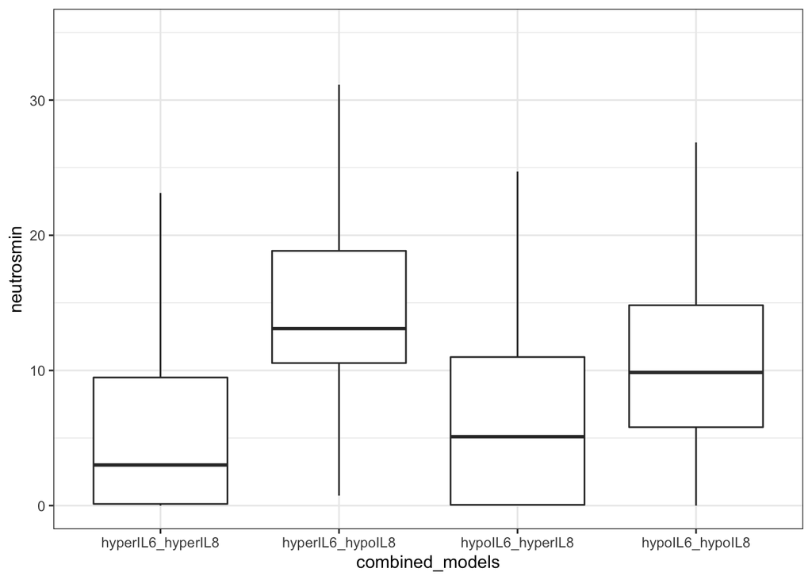

```r
ggplot(pt_all, aes(x=combined_models, y=neutrosmin)) + geom_boxplot(outlier.shape = NA) + theme_bw() + ylim(0,35)
```

```r
table(pt_all$neutropenia, pt_all$combined_models)
```

```
##
##                   hyperIL6_hyperIL8 hyperIL6_hypoIL8 hypoIL6_hyperIL8 hypoIL6_hypoIL8
##   Neutropenic                    60                1               26              12
##   Non-Neutropenic               111               18               51             178
```

```r
#can't use ChiSq b/c small group representation present in crossTab
fisher.test(table(pt_all$neutropenia, pt_all$combined_models))
```

```
##
##  Fisher's Exact Test for Count Data
##
## data:  table(pt_all$neutropenia, pt_all$combined_models)
## p-value = 6.109e-13
## alternative hypothesis: two.sided
```

## Results

Immunosuppression, and particularly neutropenia, appear to impact subphenotyping of ARDS patients when using parsimonious IL6 and IL8-based classifiers for subphenotype assignment. Plasma protein-based classifiers may be sensitive to confounders that influence expression of these plasma biomarkers. Recognizing and describing limitations and unique populations is a necessary step for future use and application of cytokine-based subphenotype classifiers in ARDS.